# Resumen

En este informe construyo un modelo de aprendizaje automático para predecir la variable **`classe`** (forma en que se realizó el ejercicio) usando los datos de acelerómetros del proyecto *Practical Machine Learning*. Sigo un flujo reproducible: descarga de datos, limpieza y preprocesamiento, partición *train/valid*, validación cruzada, comparación de modelos, estimación del error fuera de muestra y generación de predicciones para los 20 casos de prueba.

# Configuración

## Paquetes

```r
pkgs <- c("tidyverse","caret","randomForest","gbm","doParallel","janitor","vip")
need <- pkgs[!pkgs %in% installed.packages()[, "Package"]]
if(length(need)) install.packages(need, repos = "https://cloud.r-project.org")
```

```
##
##  /var/folders/02/xk0cn3pd0rb_ldnrsdrh04j40000gn/T//RtmpJMTLFZ/downloaded_packages
```

```r
invisible(lapply(pkgs, require, character.only = TRUE))
```

# Datos

Descargo los conjuntos *training* y *testing* oficiales y los leo tratando como NA a `"NA"`, `"#DIV/0!"` y cadenas vacías.

```r
train_url <- "https://d396qusza40orc.cloudfront.net/predmachlearn/pml-training.csv"
test_url  <- "https://d396qusza40orc.cloudfront.net/predmachlearn/pml-testing.csv"
train_raw <- read.csv(train_url, na.strings = c("NA", "#DIV/0!", ""))
test_raw  <- read.csv(test_url,  na.strings = c("NA", "#DIV/0!", ""))
dim(train_raw); dim(test_raw)
```

```
## [1] 19622   160
```

```
## [1]  20 160
```

# Preprocesamiento

*El objetivo es quedarnos con predictores numéricos informativos que existan tanto en `train` como en `test`.*

1. Elimino columnas no relacionadas al sensor (identificadores/tiempo/ventanas) y las de casi varianza-cero.
2. Elimino columnas con proporción de NA ≥ 95%.
3. Conservo solo variables presentes en ambos conjuntos.
4. Escalo/centro predictores numéricos con parámetros aprendidos en el set de entrenamiento.

```r
# 1) Eliminar columnas no predictoras obvias
DROP <- c("X","user_name","raw_timestamp_part_1","raw_timestamp_part_2",
          "cvtd_timestamp","new_window","num_window")
train <- train_raw %>% dplyr::select(-any_of(DROP))
test  <- test_raw  %>% dplyr::select(-any_of(DROP))

# 2) Columnas con demasiados NA (≥95%)
na_rate <- sapply(train, function(x) mean(is.na(x)))
keep_na <- names(na_rate)[na_rate < 0.95]
train <- train[, keep_na]
# Asegurar que 'classe' siga presente
stopifnot("classe" %in% names(train))

# 3) Mantener intersección de nombres entre train y test
common <- intersect(names(train), names(test))
# Nota: 'classe' no existe en test, la agregamos manualmente al conjunto de entrenamiento
train <- train %>% dplyr::select(any_of(c(common, "classe")))
test  <- test  %>% dplyr::select(any_of(common))

# Convertir outcome a factor
train$classe <- factor(train$classe)

# Near-zero variance (sobre train)
nzv <- nearZeroVar(train %>% dplyr::select(-classe), saveMetrics = TRUE)
train <- train[, c(rownames(nzv)[!nzv$nzv], "classe")]
test  <- test[, rownames(nzv)[!nzv$nzv]]

# 4) Center/scale sobre columnas numéricas
num_cols <- names(train)[sapply(train, is.numeric)]
pp <- preProcess(train[, num_cols], method = c("center","scale"))
train[, num_cols] <- predict(pp, train[, num_cols])
test[,  num_cols] <- predict(pp, test[,  num_cols])

# Vista rápida
list(
  n_predictors = ncol(train) - 1,
  n_rows_train = nrow(train),
  n_rows_test  = nrow(test)
)
```

```
## $n_predictors
## [1] 52
##
## $n_rows_train
## [1] 19622
##
## $n_rows_test
## [1] 20
```

# Partición de datos

Uso una partición estratificada 70/30 para estimar el error fuera de muestra.

```r
set.seed(20250904)
split <- createDataPartition(train$classe, p = 0.7, list = FALSE)
train_set <- train[split, ]
valid_set <- train[-split, ]
dim(train_set); dim(valid_set)
```

```
## [1] 13737    53
```

```
## [1] 5885   53
```

# Modelado y validación cruzada

Entreno y comparo dos modelos fuertes para este tipo de datos: **Random Forest (RF)** y **Gradient Boosting (GBM)**. Ambos con validación cruzada de 5 *folds*.

```r
ctrl <- trainControl(method = "cv", number = 5, allowParallel = TRUE)
cl <- parallel::makePSOCKcluster(max(1, parallel::detectCores() - 1))
doParallel::registerDoParallel(cl)

set.seed(20250904)
rf_fit <- train(classe ~ ., data = train_set,
                method = "rf", trControl = ctrl,
                ntree = 500, importance = TRUE)

set.seed(20250904)
gbm_fit <- train(classe ~ ., data = train_set,
                 method = "gbm", trControl = ctrl,
                 verbose = FALSE)

stopCluster(cl); registerDoSEQ()

rf_fit; gbm_fit
```

```
## Random Forest
##
## 13737 samples
##    52 predictor
##     5 classes: 'A', 'B', 'C', 'D', 'E'
##
## No pre-processing
## Resampling: Cross-Validated (5 fold)
## Summary of sample sizes: 10988, 10990, 10988, 10991, 10991
## Resampling results across tuning parameters:
##
##   mtry  Accuracy   Kappa
##    2    0.9909002  0.9884882
##   27    0.9886435  0.9856334
##   52    0.9802706  0.9750393
##
## Accuracy was used to select the optimal model using the largest value.
## The final value used for the model was mtry = 2.
```

```
## Stochastic Gradient Boosting
##
## 13737 samples
##    52 predictor
##     5 classes: 'A', 'B', 'C', 'D', 'E'
##
## No pre-processing
## Resampling: Cross-Validated (5 fold)
## Summary of sample sizes: 10988, 10990, 10988, 10991, 10991
## Resampling results across tuning parameters:
##
##   interaction.depth  n.trees  Accuracy   Kappa
##   1                   50      0.7503081  0.6834491
##   1                  100      0.8215775  0.7741082
##   1                  150      0.8552087  0.8167779
##   2                   50      0.8557174  0.8172028
##   2                  100      0.9079850  0.8835427
##   2                  150      0.9310602  0.9127612
##   3                   50      0.8959017  0.8681665
##   3                  100      0.9400890  0.9241912
##   3                  150      0.9584322  0.9474103
##
## Tuning parameter 'shrinkage' was held constant at a value of 0.1
##
## Tuning parameter 'n.minobsinnode' was held constant at a value of 10
## Accuracy was used to select the optimal model using the largest value.
## The final values used for the model were n.trees = 150, interaction.depth =
##  3, shrinkage = 0.1 and n.minobsinnode = 10.
```

### Comparación por *resamples*

```r
res <- resamples(list(RF = rf_fit, GBM = gbm_fit))
summary(res)
```

```
##
## Call:
## summary.resamples(object = res)
##
## Models: RF, GBM
## Number of resamples: 5
##
## Accuracy
##          Min.   1st Qu.    Median      Mean   3rd Qu.      Max. NA's
## RF  0.9894392 0.9901675 0.9909058 0.9909002 0.9919913 0.9919971    0
## GBM 0.9522942 0.9566642 0.9596217 0.9584322 0.9614405 0.9621405    0
##
## Kappa
##          Min.   1st Qu.    Median      Mean   3rd Qu.      Max. NA's
## RF  0.9866396 0.9875592 0.9884963 0.9884882 0.9898695 0.9898763    0
## GBM 0.9396448 0.9451826 0.9489032 0.9474103 0.9511961 0.9521250    0
```

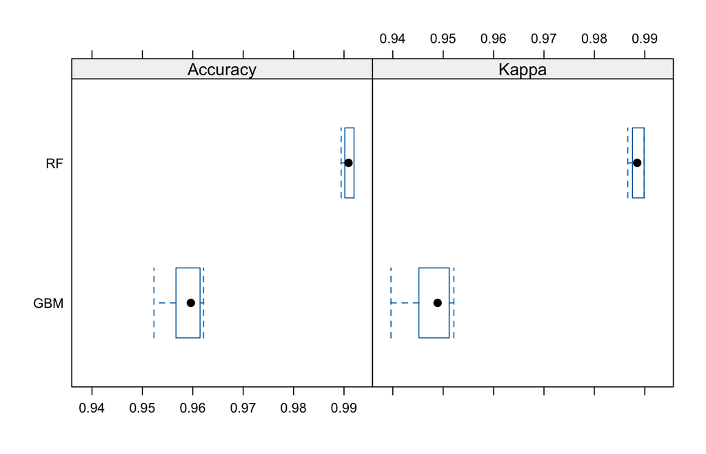

```r
lattice::bwplot(res)
```

# Evaluación en el conjunto de validación

```r
rf_pred_v <- predict(rf_fit, valid_set)
cm_rf <- confusionMatrix(rf_pred_v, valid_set$classe)
cm_rf
```

```
## Confusion Matrix and Statistics
##
##           Reference
## Prediction    A    B    C    D    E
##          A 1674    5    0    0    0
##          B    0 1132    6    0    0
##          C    0    2 1020   13    0
##          D    0    0    0  951    1
##          E    0    0    0    0 1081
##
## Overall Statistics
##
##                Accuracy : 0.9954
##                  95% CI : (0.9933, 0.997)
##     No Information Rate : 0.2845
##     P-Value [Acc > NIR] : < 2.2e-16
##
##                   Kappa : 0.9942
##
##  Mcnemar's Test P-Value : NA
##
## Statistics by Class:
##
##                      Class: A Class: B Class: C Class: D Class: E
## Sensitivity            1.0000   0.9939   0.9942   0.9865   0.9991
## Specificity            0.9988   0.9987   0.9969   0.9998   1.0000
## Pos Pred Value         0.9970   0.9947   0.9855   0.9989   1.0000
## Neg Pred Value         1.0000   0.9985   0.9988   0.9974   0.9998
## Prevalence             0.2845   0.1935   0.1743   0.1638   0.1839
## Detection Rate         0.2845   0.1924   0.1733   0.1616   0.1837
## Detection Prevalence   0.2853   0.1934   0.1759   0.1618   0.1837
## Balanced Accuracy      0.9994   0.9963   0.9955   0.9932   0.9995
```

```r
err_rf <- 1 - cm_rf$overall["Accuracy"]

gbm_pred_v <- predict(gbm_fit, valid_set)
cm_gbm <- confusionMatrix(gbm_pred_v, valid_set$classe)
cm_gbm
```

```
## Confusion Matrix and Statistics
##
##           Reference
## Prediction    A    B    C    D    E
##          A 1649   35    0    0    4
##          B   18 1079   29    5    5
##          C    4   25  980   40    4
##          D    3    0   16  908   10
##          E    0    0    1   11 1059
##
## Overall Statistics
##
##                Accuracy : 0.9643
##                  95% CI : (0.9593, 0.9689)
##     No Information Rate : 0.2845
##     P-Value [Acc > NIR] : < 2.2e-16
##
##                   Kappa : 0.9548
##
##  Mcnemar's Test P-Value : 2.662e-05
##
## Statistics by Class:
##
##                      Class: A Class: B Class: C Class: D Class: E
## Sensitivity            0.9851   0.9473   0.9552   0.9419   0.9787
## Specificity            0.9907   0.9880   0.9850   0.9941   0.9975
## Pos Pred Value         0.9769   0.9498   0.9307   0.9691   0.9888
## Neg Pred Value         0.9940   0.9874   0.9905   0.9887   0.9952
## Prevalence             0.2845   0.1935   0.1743   0.1638   0.1839
## Detection Rate         0.2802   0.1833   0.1665   0.1543   0.1799
## Detection Prevalence   0.2868   0.1930   0.1789   0.1592   0.1820
## Balanced Accuracy      0.9879   0.9677   0.9701   0.9680   0.9881
```

```r
err_gbm <- 1 - cm_gbm$overall["Accuracy"]

best_name <- ifelse(cm_rf$overall["Accuracy"] >= cm_gbm$overall["Accuracy"], "RF", "GBM")
err_best <- ifelse(best_name == "RF", err_rf, err_gbm)
knitr::kable(data.frame(Modelo = c("RF","GBM"),
                        Accuracy = c(cm_rf$overall["Accuracy"], cm_gbm$overall["Accuracy"]),
                        ErrorFueraDeMuestra_Estimado = c(err_rf, err_gbm)))
```

| Modelo | Accuracy | ErrorFueraDeMuestra_Estimado |
| --- | --- | --- |
| RF | 0.9954121 | 0.0045879 |
| GBM | 0.9643161 | 0.0356839 |